# Plans d’expériences

2 décembre 2020

## Simulations numériques

## Modélisation

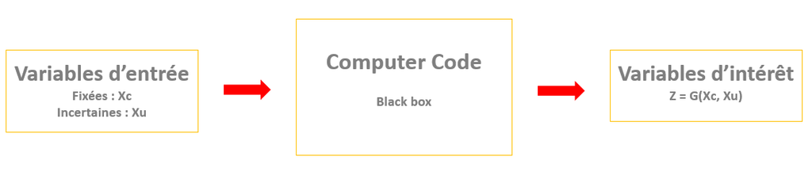

**Variables d’entrée :**

- Scalaires
- Vectorielles
- Fonctionelles (spatialles, temporelles, spatio-temporelles)

**Variables d’intérêt :**

- Scalaires
- Vectorielles
- Fonctionelles (spatialles, temporelles, spatio-temporelles)

## Exemple

### Etude d’une inondation de zone cotière

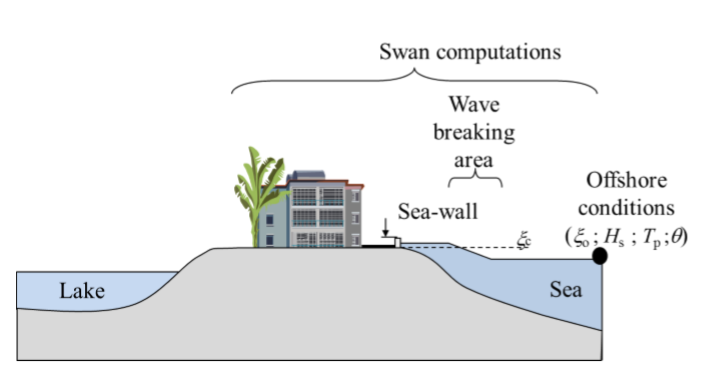

- Variables fixées : Dimensionnement des protections
- Variables incertaines : Conditions maritimes au large
- Variable d’intérêt : Niveau d’eau à un endroit donnée
- Computer code : Modélisateur hydraulique

## Objectifs possibles

- Analyse de sensibilité : Trouver les variables les plus influentes, quantifier leur impact..
- Optimisation : Trouver le minimum ou le maximum de G (possiblement à \(X_{c}\) fixé)
- Inversion : Déterminer \(\Gamma_{x_{u}} = \{x_{c}, \: G(x_{c}, x_{u})\: > \: seuil\}\) ou \(\Gamma = \{x_{c}, \:P(\: G(x_{c}, X_{u}) \: > \: seuil) \: > \: \alpha\}\)

## Problème

Ces objectifs requièrent des milliers d’appels au simulateurs

Or, temps de calcul du modélisateur très élevé : plusieurs jours

Approche statistique :

- Plans d’expériences
- Métamodèle

**\(\Rightarrow\) Où faire les quelques simulations envisageables et quel métamodèle choisir pour atteindre un des objectifs précédents ?**

## Intérêt du métamodèle

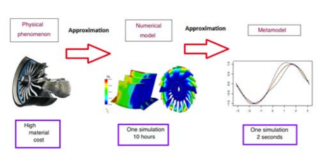

## Introduction aux plans d’expériences pour simulations numériques

## Objectifs

- Explorer le comportement des réponses d’un code à l’aide d’un nombre limité de calculs
- Propager les incertitudes (calcul des moments des réponses)
- Fournir des plans plus efficaces que les plans aléatoires purs pour estimer des indices de sensibilité
- Fournir un plan initial pour construire un métamodèle

## Spécificité des plans pour simulations numériques

- Expériences déterministes (erreur=0)
- grand nombre de facteurs
- larges domaines de variation
- variables d’intérêt multiples
- modèles fortement non linéaires

\(\Rightarrow\) space filling designs

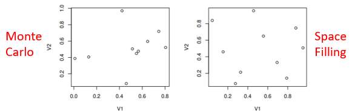

## Critères de remplissage d’espace

## Critère géométrique Maximin

Le design Maximin maximise la distance minimale entre les points du plan

On pose \(\mathbb{X} = (x_{1},x_{2},...,x_{n})\) avec \(\forall 1\leq i \leq n, x_{i} \in \mathbb{D}\) (on pourra prendre \(\mathbb{D}=\left[0,1\right]^{p}\))

On définit : \[\Phi_{Mm}(\mathbb{X}) = \min\limits_{(x_{i}, x_{k}) \in \mathbb{X}^{2}, i \neq k} \|x_{i} - x_{k}\|\]

\(\Phi_{Mm}\) est une mesure du remplissage de l’espace \(\mathbb{D}\) par le plan \(\mathbb{X}\)

\(\mathbb{X}_{Mm}^{*}\:=\:\) **arg**\(\max\limits_{\mathbb{X}}\: \Phi_{Mm}(\mathbb{X})\) est appelé plan d’expériences maximin

## Visualisation du critère Maximin

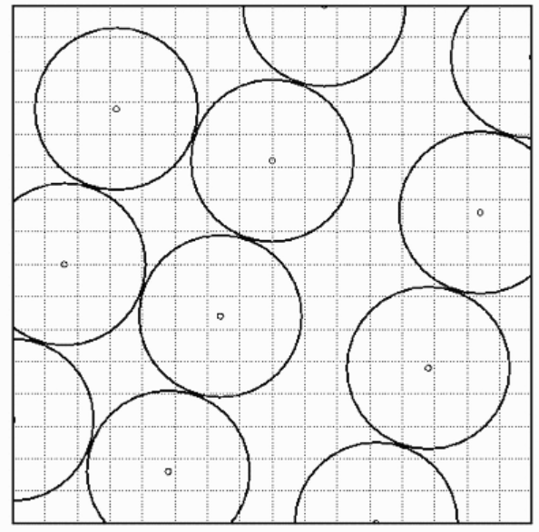

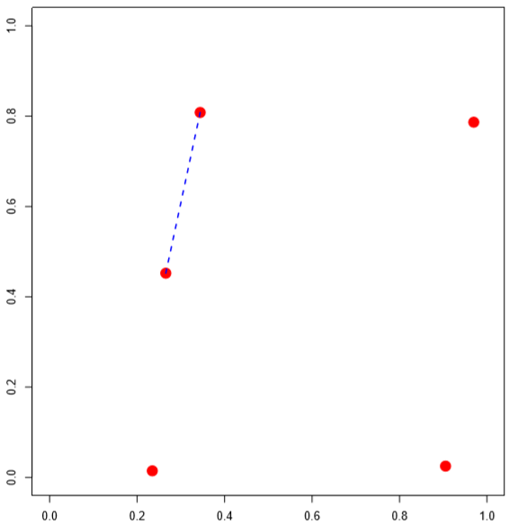

\(\Phi_{Mm}(\mathbb{X})=2\rho\) où \(\rho\) est le plus petit rayon r tel que l’ensemble des cercles de rayon r ayant pour centre les points du plan ne sont pas tous disjoints 2 à 2.

## Critère géométrique : miniMax

Le design miniMax minimise la distance maximale entre un point du domaine et le plan

On définit la distance entre un point \(x \in \mathbb{D}\) et un design \(\mathbb{X}\) : \(d(x, \mathbb{X})\:=\: \min\limits_{x_{i} \in \mathbb{X}} \|x_{i} - x\|\)

On définit maintenant : \[\Phi_{mM}(\mathbb{X}) = \max\limits_{x \in \mathbb{D}} d(x,\mathbb{X})\]

\(\Phi_{mM}\) est également une mesure du remplissage de l’espace \(\mathbb{D}\) par le plan \(\mathbb{X}\)

\(\mathbb{X}_{mM}^{*}\:=\:\) **arg**\(\min\limits_{\mathbb{X}}\: \Phi_{mM}(\mathbb{X})\) est appelé plan d’expériences minimax

## Visualisation du critère miniMax

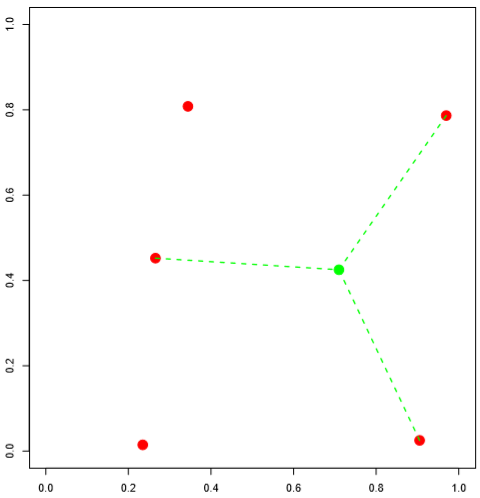

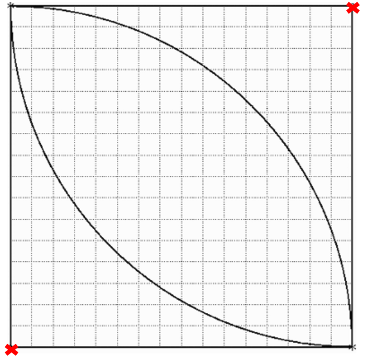

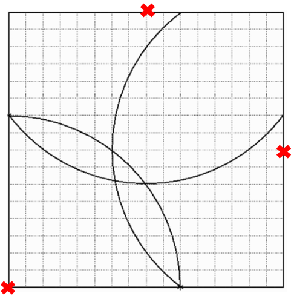

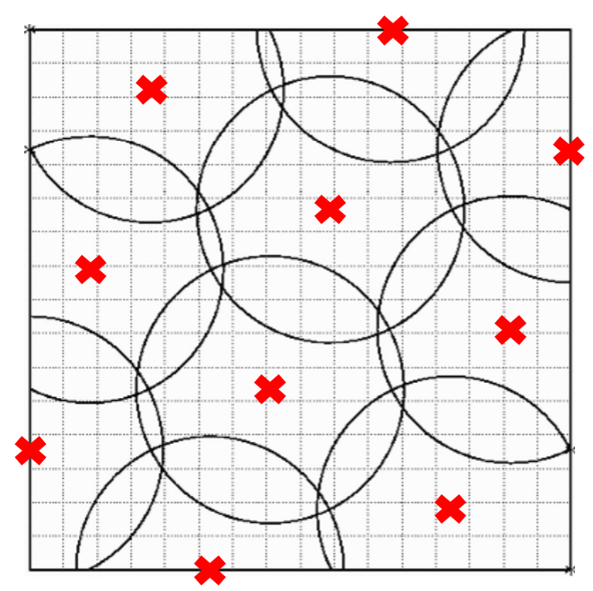

\(\Phi_{mM}(\mathbb{X})=\rho\) où \(\rho\) est le plus petit rayon r tel que la réunion des disques de rayon r ayant pour centre les points du plan couvre l’ensemble du plan.

## Excercice

1. En 1D, avec \(\mathbb{D} = \left[0,1\right]\) donner le plan Maximin à 2 points, 3 points.. Puis en déduire celui à n points. Calculer à chaque fois \(\Phi_{Mm}(\mathbb{X})\) et \(\Phi_{mM}(\mathbb{X})\).
2. Faire la même chose avec les plans minimax.

## Correction Exercice

1. \(\mathbb{X}=\{x_{i}=\frac{i-1}{n-1}, \: 1\leq i\leq n\}\: ; \: \Phi_{Mm}(\mathbb{X})=\frac{1}{n-1}, \: ; \: \Phi_{mM}(\mathbb{X})=\frac{1}{2(n-1)}\)
2. \(\mathbb{X}=\{x_{i}=\frac{2i-1}{2n}, \: 1\leq i\leq n\}\: ; \: \Phi_{Mm}(\mathbb{X})=\frac{1}{n}, \: ; \: \Phi_{mM}(\mathbb{X})=\frac{1}{2n}\)

## Critère statistique : la discrépance

La discrepance mesure la déviation maximale entre la répartition des points du plan et une répartition uniforme

On prend \(\mathbb{D} = \left[0,1\right]^{p}\) et on pose \(Q(t) = \left[0,t_{1}\right]\times\left[0,t_{2}\right]\times...\times\left[0,t_{p}\right]\)

On définit la discrépance comme suit :

\(D_{n}(\mathbb{X}) = \sup\limits_{t \in \left[0,1\right[^{p}}|\:\frac{n_{Q(t)}}{n} - vol(Q(t))\:|\) avec \(vol(Q(t)) = \displaystyle\prod_{i=1}^{p}t_{i}\)

avec \(\frac{n_{Q(t)}}{n}\) égal à la proportion de points de points du plan dans \(Q(t)\)

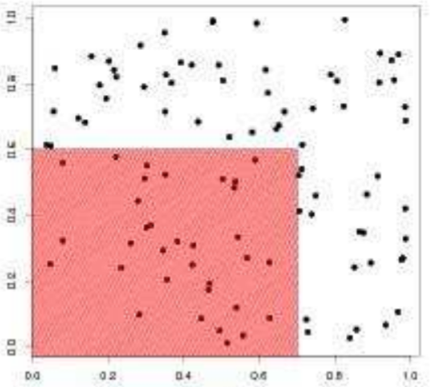

D’autres formulations existent :

\(D_{n_{L_{2}}}(\mathbb{X}) = \left[\: \int_{\left[0,1\right[^{p}} \left[\:\frac{n_{Q(t)}}{n} - vol(Q(t))\: \right]^{2}\:dt \: \right] ^{1/2}\)

## Suites uniformément distribuées

**Définition :** On appelle suite uniformément distribuée une suite \(u\) qui vérifie :

\(\forall \mathcal{J}\) sous-intervalle de \(\left[0,1\right]^{p}\), \[\lim\limits_{n \to \infty} \frac{1}{n}\displaystyle\sum_{i=1}^{n}\:\mathbb{1}_{u_{n}\in \mathcal{J}} \:=\: vol(\mathcal{J})\] où \(\mathbb{1}_{u_{n}\in \mathcal{J}}\) est la fonction indicatrice de \(\mathcal{J}\) appliquée en \(u_{n}\)

Dit autrement, \(\forall \mathcal{J}\), la proportion de points dans \(\mathcal{J}\) tend vers le volume de \(\mathcal{J}\)

**Propriété :** Une suite \((u_{n})\) est uniformément distribuée si et seulement si \(\lim\limits_{n \to \infty}D_{n}(\mathbb{U}_{n} = (u_{1},..,u_{n}))\:=\:0\)

## Lien avec le problème de l’intégration d’une fonction

\(I = \int_{\left[0,1\right]^{p}}F(x)dx\)

Propriété générale (Koksma Hlawka) : \(\epsilon = |\:I\:-\:\frac{1}{n}\displaystyle\sum_{i=1}^{n}F(x_{i})\:|\:\leq\:V(F)\times D_{n}(\mathbb{X})\)

où \(V(F)\) est la variation de F et ne reflète que l’irrégularité de la fonction F

En dimension 1, pour une fonction F dérivable de dérivée intégrable sur \(\left[0,1\right]\) : \(V(F) = \int_{\left[0,1\right]}|F'(x)|dx\)

Monte Carlo basique : \(\epsilon = O(\frac{1}{\sqrt{n}})\)

Suite à faible discrépance : \(\epsilon = O(\frac{ln(n)^{p}}{n})\)

## Suites à faible discrépance

## Problématique en 1D

On va vouloir construire une suite \((u_{n})\) de discrépance minimale.

Il peut être démontré que pour tout ensemble de points \(\{u_{1},..,u_{n}\}\), \[D_{n}(u_{1},..,u_{n}) \geq \frac{1}{2n}\] avec égalité quand \(u_{i} = \frac{2i-1}{2n}\)

Problème : La position des n points optimaux dépend de n (le nombre de points), donc si l’on veut rajouter des points en conservant la discrépance minimale, on ne peut pas conserver les n premiers points générés

Il a même été démontré que : \[\exists c \in \mathbb{R}, \forall u \in \left[0,1\right]^\mathbb{N}, \forall n \in \mathbb{N}, D_{n}(u_{1},..,u_{n}) \geq c\frac{log(n)}{n}\] \(\Rightarrow\) Construction de suites dont la discrépance est de l’ordre de la borne ci-dessus

## Suites de Van der Corput : base b

Les suites de Van der Corput sont basés sont l’écriture en base b d’un entier n.

En effet, chaque entier n a une unique écriture en base b : \[n = \displaystyle\sum_{j=0}^{\infty}a_{j}(n,b)b^{j}\] où \(\forall j,\: a_{j}(n,b) \in \{0,1,..,b-1\}\) et \(a_{j}(n,b) = 0\) pour j suffisamment grand

## Suites de Van der Corput : exercice base b

Compléter les valeurs de n en base b pour les b et n ci-dessous :

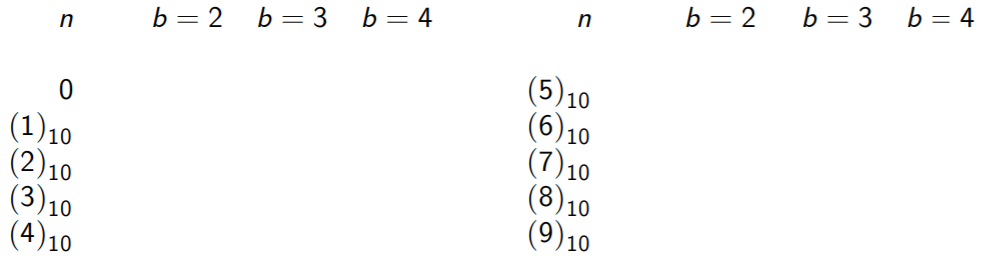

## Suites de Van der Corput : correction exercice base b

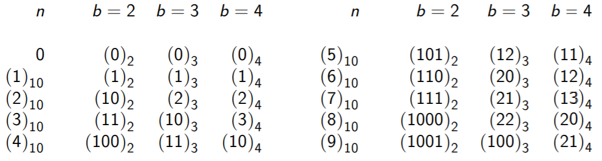

## Suites de Van der Corput : Définition

Pour tout entier \(b \geq 2\), on pose : \[\Phi_{b}(n)\: = \: \displaystyle\sum_{j=0}^{\infty}a_{j}(n,b)b^{-j-1}\] La suite de Van der Corput en base b est ainsi : \[C_{b}\:=\:\{\Phi_{b}(n), n\in \mathbb{N}\}\]

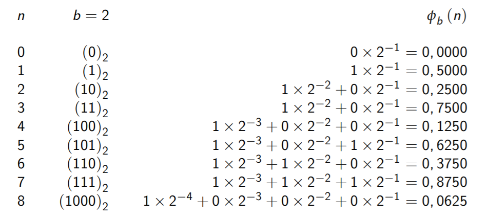

## Suites de Halton : Définition

Les suites de Halton sont une extension naturelle en dimension d des suites de Van der Corput

Soient \(b_{1},...,b_{p}\) p entiers supérieurs ou égaux à 2. La suite de Halton en dimension d est : \[H_{b_{1},..,b_{p}}\:=\:\{u_{n}, n\in \mathbb{N}\}\] où \(u_{n}\:=\:(\Phi_{b_{1}}(n),..,\Phi_{b_{p}}(n))\)

**Attention :** Les \(b_{i}\) doivent être premiers entre eux

[figure not shown]

## Suites de Halton : Visualisation

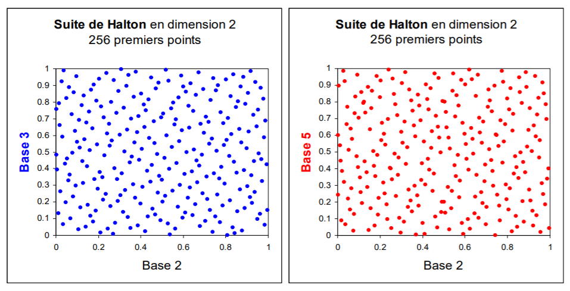

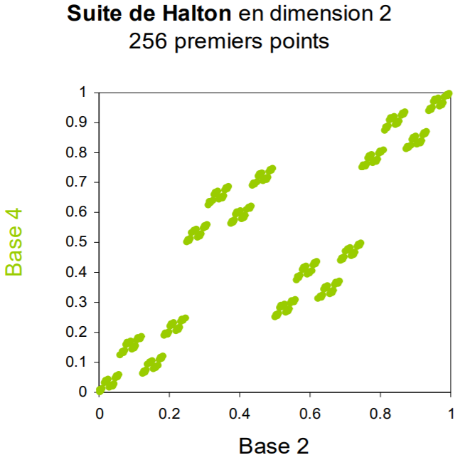

## Autres suites à faibles discrépances : suites de Sobol

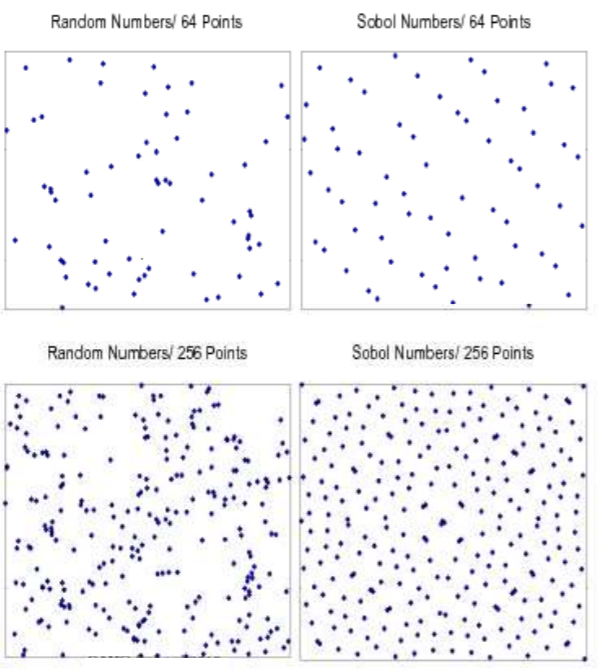

## Pathologie sur les projections en dimensions inférieures - Halton

Exemple avec 150 points en 8 dimensions pour la suite de Halton

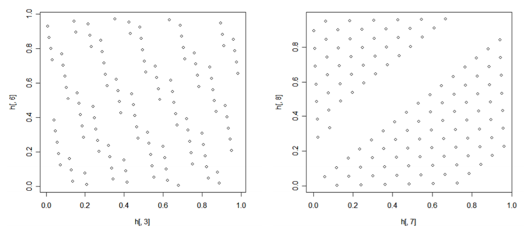

## Pathologie sur les projections en dimensions inférieures - Sobol

Exemple avec 100 points (gauche) 150 points (droite) en 8 dimensions pour la suite de Sobol, avec projection sur les axes 7 et 8

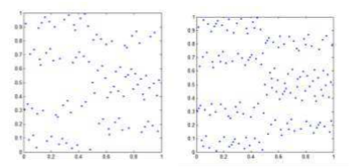

Importance de la robustesse dans les dimensions inférieures : le code de calcul \(G(X)\) a souvent de faibles dimensions effectives (nb de variables influentes \(<< p\))

## Hypercubes latins (LHS)

## LHS : Principe

On note \(LHS(p,n)\) un \(LHS\) à p variables et n points.

L’idée est la suivante :

- On divise chaque dimension en \(n\) intervalles égaux : on obtient ainsi \(n^{d}\) cellules de même taille (produit cartésien des intervalles)
- On choisit \(n\) cellules parmi les \(n^{d}\) obtenues, en faisant en sorte que chaque intervalle de chaque dimension ne soit représentées qu’une fois
- On tire au hasard un point dans chacune des \(n\) cellules selectionnées

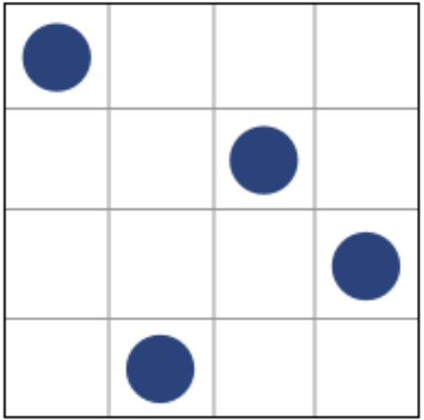

## LHS : formulation

Un LHS \(n\) points sur \(\left[0,1\right]^{d}\) est défini par l’ensemble des points \(x^{i}\) tels que : \[ x^{i}_{j}=\frac{\pi_{j}(i)-u_{j}^{i}}{n},\;1\leq i\leq n,\;1\leq j\leq n \]

où \(\pi_{j}\) est une permutation de \(\{1,..,n\}\) et \(u_{j}^{i}\) est une réalisation de la variable aléatoire \(U_{j}^{i}\) avec \(U_{j}^{i}\sim \mathcal{U}(0,1)\)

Remarque : Les \(U_{j}^{i}\) peuvent suivre d’autres lois, et même par exemple placer les points au centre des cellules

## LHS : exemples

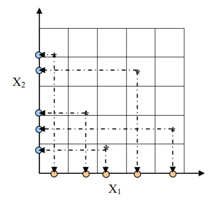

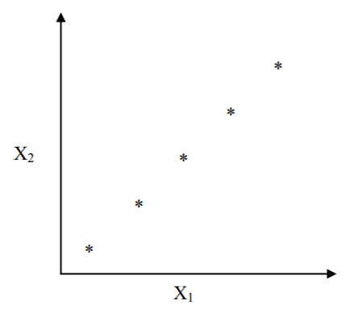

Sans prendre en compte l’aléa dû à la réalisation de la variable aléatoire uniforme, il y a \((n!)^{p-1}\) LHS possibles ! (et non \((n!)^{p}\) car on ne tient pas compte de l’ordre des points)

## LHS : optimisation

Idée : Optimisation d’un des critère de remplissage d’espace

Comme le nombre de LHS est très grand, on peut faire appel à des algorithmes d’optimisation adaptés, pour ne pas parcourir l’ensemble des possibilités

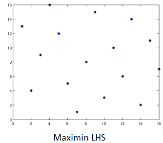

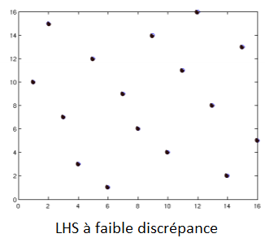

## Conclusion

## Bilan sur les plans d’expériences numériques

**Enjeu :** Echantillonner un espace de grande dimension de manière « optimale » (obtenir le plus d’informations sur le comportement de la sortie)

Problème : Un échantillon aléatoire (Monte Carlo) remplit mal l’espace

1. **Plans “space filling”** sont de bons candidats pour bien remplir l’espace :
   - Basés sur un critère de remplissage d’espace (minimax, maximin)
   - Basés sur un critère de répartition uniforme des points (discrépance)
2. Ces plans peuvent avoir des problèmes de projections en dimensions inférieures. Les **hypercubes latins (LHS)** y remédient pour les projections en dimension 1.
3. Il est possible de coupler les 2 propriétés avec des **LHS optimisés**